# HW1_Blumentals

2023-10-22

# 1. mājasdarbs

## 1. uzdevums

### Aprakstoša statistika

```r
library(readxl)
library(ggplot2)

diabetes_data <- read_excel("homeworks\\data\\HW1\\diabetes.xlsx")

# Datus veidi/tipi
str(diabetes_data)
```

```
## tibble [107 × 44] (S3: tbl_df/tbl/data.frame)
##  $ Dzimšanas dati                                                     : POSIXct[1:107], format: "1992-03-08" "1968-07-24" ...
##  $ Grupa                                                              : chr [1:107] "T1D" "T1D" "T1D" "T1D" ...
##  $ Dzimums                                                            : num [1:107] 2 2 1 2 2 2 2 2 2 2 ...
##  $ Augums, m                                                          : num [1:107] 1.71 1.67 1.74 1.6 1.76 1.62 1.69 1.67 1.7 1.73 ...
##  $ Svars, kg                                                          : num [1:107] 107 79 78 54 93 80 71 67 80.8 72 ...
##  $ Vidukļa-auguma attiecība                                           : num [1:107] 0.637 0.551 0.529 0.428 0.534 ...
##  $ KMI                                                                : num [1:107] 36.6 28.3 25.8 21.1 30 30.5 24.9 24 28 24.1 ...
##  $ Gurni, cm                                                          : num [1:107] 127 110 104 92 119 108 107 100 107 97 ...
##  $ Vidukļa-gurnu attiecība                                            : num [1:107] 0.86 0.84 0.88 0.74 0.79 0.81 0.84 0.9 0.98 0.75 ...
##  $ Viduklis, cm                                                       : num [1:107] 109 92 92 68.5 94 87 90 90 105 73 ...
##  $ SAS, mmHg                                                          : num [1:107] 124 135 154 161 133 117 120 176 159 132 ...
##  $ DAS, mmHg                                                          : num [1:107] 80 89 97 98 72 65 76 106 79 76 ...
##  $ Hipertensija                                                       : num [1:107] 0 1 1 1 1 1 0 1 1 1 ...
##  $ Smeķēšana                                                          : num [1:107] 0 0 2 1 0 2 1 2 0 0 ...
```

[output cut: 30 more lines]

```r
# Aprakstošā statistika
summary(diabetes_data)
```

```
##  Dzimšanas dati                       Grupa              Dzimums
##  Min.   :1942-06-06 00:00:00.000   Length:107         Min.   :1.000
##  1st Qu.:1971-10-31 12:00:00.000   Class :character   1st Qu.:1.000
##  Median :1981-07-30 00:00:00.000   Mode  :character   Median :2.000
##  Mean   :1979-12-15 21:45:25.234                      Mean   :1.607
##  3rd Qu.:1987-12-15 00:00:00.000                      3rd Qu.:2.000
##  Max.   :2019-04-25 00:00:00.000                      Max.   :2.000
##
##    Augums, m       Svars, kg      Vidukļa-auguma attiecība      KMI
##  Min.   :1.430   Min.   : 47.00   Min.   :0.3473           Min.   :18.40
##  1st Qu.:1.655   1st Qu.: 67.00   1st Qu.:0.4395           1st Qu.:22.40
##  Median :1.700   Median : 76.00   Median :0.4824           Median :24.40
##  Mean   :1.722   Mean   : 76.47   Mean   :0.4981           Mean   :25.78
##  3rd Qu.:1.790   3rd Qu.: 84.00   3rd Qu.:0.5425           3rd Qu.:28.30
##  Max.   :1.990   Max.   :123.20   Max.   :0.7083           Max.   :40.20
##
##    Gurni, cm     Vidukļa-gurnu attiecība  Viduklis, cm      SAS, mmHg
##  Min.   : 74.0   Min.   :0.6200          Min.   : 58.00   Min.   : 96.0
##  1st Qu.: 96.5   1st Qu.:0.7700          1st Qu.: 75.00   1st Qu.:113.5
##  Median :103.0   Median :0.8200          Median : 84.00   Median :121.0
##  Mean   :102.1   Mean   :0.8373          Mean   : 85.62   Mean   :124.7
##  3rd Qu.:107.0   3rd Qu.:0.8950          3rd Qu.: 93.00   3rd Qu.:134.5
##  Max.   :127.0   Max.   :1.1600          Max.   :128.00   Max.   :176.0
##
##    DAS, mmHg       Hipertensija      Smeķēšana       CD Dg. gads
##  Min.   : 61.00   Min.   :0.0000   Min.   :0.0000   Min.   :1965
##  1st Qu.: 72.00   1st Qu.:0.0000   1st Qu.:0.0000   1st Qu.:1989
##  Median : 78.00   Median :0.0000   Median :0.0000   Median :2000
##  Mean   : 78.75   Mean   :0.3925   Mean   :0.3738   Mean   :1998
##  3rd Qu.: 85.50   3rd Qu.:1.0000   3rd Qu.:1.0000   3rd Qu.:2008
##  Max.   :106.00   Max.   :1.0000   Max.   :2.0000   Max.   :2016
##                                                     NA's   :33
##  CD retinopātija   Albuminūrija    Akūts miokarda infarkts    Insults
##  Min.   :0.0000   Min.   :0.0000   Min.   :0.00000         Min.   :0.00000
##  1st Qu.:0.0000   1st Qu.:0.0000   1st Qu.:0.00000         1st Qu.:0.00000
##  Median :0.0000   Median :0.0000   Median :0.00000         Median :0.00000
##  Mean   :0.2991   Mean   :0.1028   Mean   :0.02804         Mean   :0.03738
##  3rd Qu.:1.0000   3rd Qu.:0.0000   3rd Qu.:0.00000         3rd Qu.:0.00000
##  Max.   :1.0000   Max.   :1.0000   Max.   :1.00000         Max.   :1.00000
##
```

[output cut: 57 more lines]

```
##  Min.   :0.2000               Min.   :  0.00      Min.   : 26.97
##  1st Qu.:0.2000               1st Qu.:  3.10      1st Qu.: 92.29
##  Median :0.4000               Median :  6.30      Median :107.05
##  Mean   :0.5538               Mean   : 21.49      Mean   :103.23
##  3rd Qu.:0.7750               3rd Qu.: 16.10      3rd Qu.:116.60
##  Max.   :2.4000               Max.   :258.10      Max.   :157.97
##  NA's   :1                    NA's   :10
##  Plate LBP mērījumam      LBP
##  Length:107          Min.   : 0.1715
##  Class :character    1st Qu.: 5.9650
##  Mode  :character    Median : 7.9267
##                      Mean   : 9.9073
##                      3rd Qu.:13.1781
##                      Max.   :29.0500
##                      NA's   :4
```

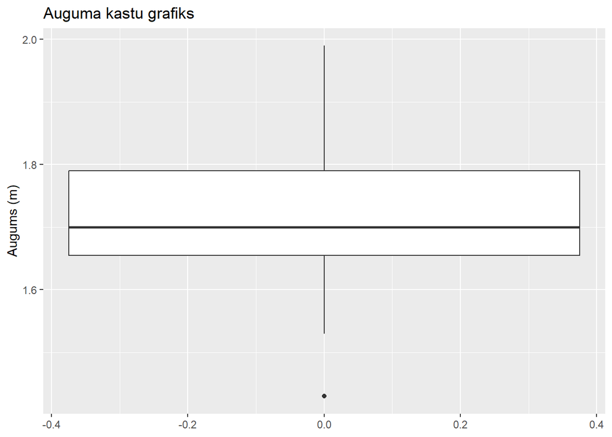

```r
# Kastu grafiks par Augumu
kastu_grafiks_augums <- ggplot(diabetes_data, aes(y=`Augums, m`)) +
  geom_boxplot() +
  ggtitle("Auguma kastu grafiks") +
  ylab("Augums (m)")
print(kastu_grafiks_augums)
```

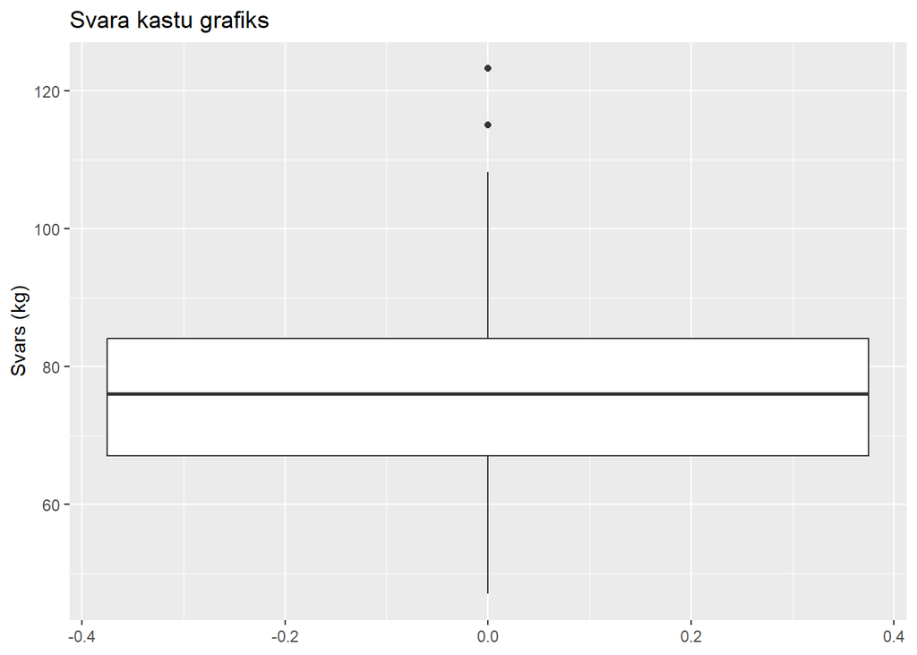

```r
# Kastu grafiks par Svaru
kastu_grafiks_svars <- ggplot(diabetes_data, aes(y=`Svars, kg`)) +
  geom_boxplot() +
  ggtitle("Svara kastu grafiks") +
  ylab("Svars (kg)")
print(kastu_grafiks_svars)
```

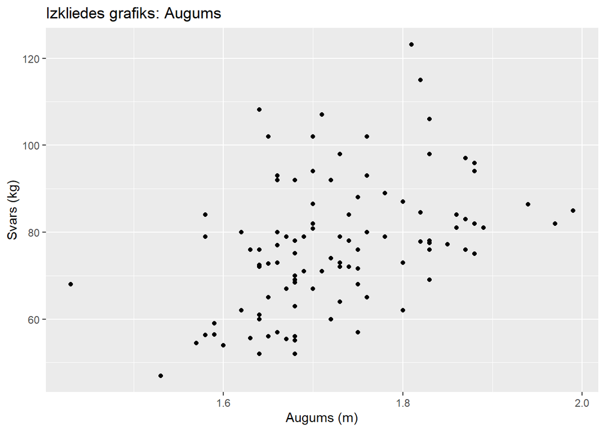

```r
# Izkliedes grafiks starp Augumu un Svaru
scatter_augums_svars <- ggplot(diabetes_data, aes(x=`Augums, m`, y=`Svars, kg`)) +
  geom_point() +
  ggtitle("Izkliedes grafiks: Augums") +
  xlab("Augums (m)") + ylab("Svars (kg)")
print(scatter_augums_svars)
```

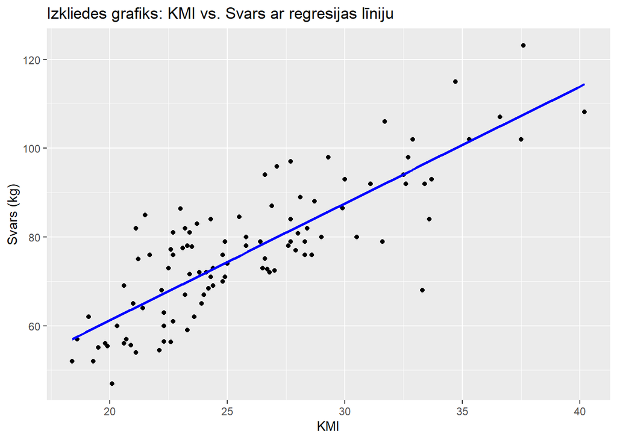

```r
# Izkliedes grafiks starp KMI un Svaru ar regresijas līniju
scatter_KMI_svars <- ggplot(diabetes_data, aes(x=KMI, y=`Svars, kg`)) +
  geom_point() +
  geom_smooth(method=lm, se=FALSE, color="blue") +
  ggtitle("Izkliedes grafiks: KMI vs. Svars ar regresijas līniju") +
  xlab("KMI") + ylab("Svars (kg)")
print(scatter_KMI_svars)
```

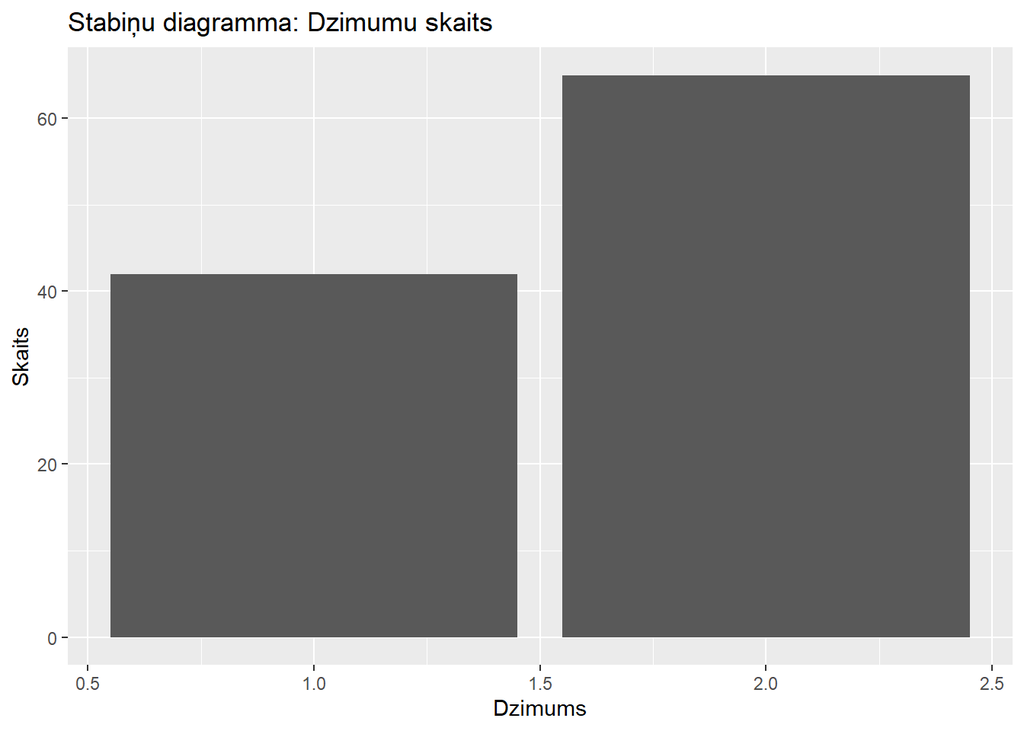

```r
# Stabiņu diogramma par dzimumu skaitu
barplot_dzimums <- ggplot(diabetes_data, aes(x=Dzimums)) +
  geom_bar() +
  ggtitle("Stabiņu diagramma: Dzimumu skaits") +
  xlab("Dzimums") + ylab("Skaits")
print(barplot_dzimums)
```

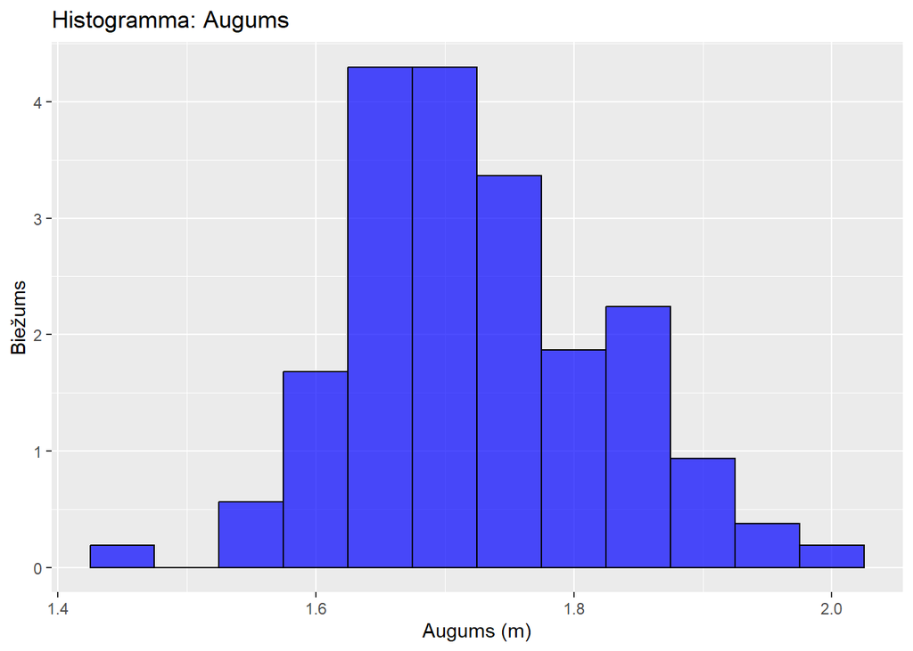

```r
# Histogramma par Augumu
hist_augums <- ggplot(diabetes_data, aes(x=`Augums, m`)) +
  geom_histogram(aes(y=..density..), binwidth=0.05, fill="blue", color="black", alpha=0.7) +
  ggtitle("Histogramma: Augums") +
  xlab("Augums (m)") + ylab("Biežums")
print(hist_augums)
```

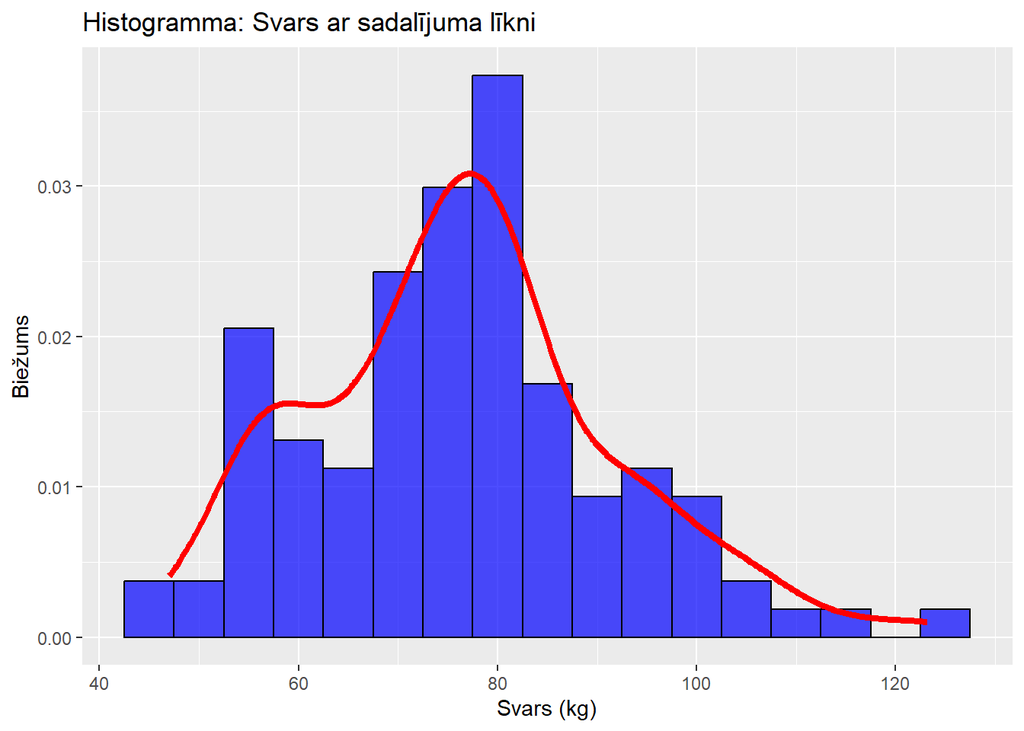

```r
# Histogramma par Svaru ar sadalījuma līkni
hist_svars <- ggplot(diabetes_data, aes(x=`Svars, kg`)) +
  geom_histogram(aes(y=..density..), binwidth=5, fill="blue", color="black", alpha=0.7) +
  geom_density(color="red", size=1.5) +
  ggtitle("Histogramma: Svars ar sadalījuma līkni") +
  xlab("Svars (kg)") + ylab("Biežums")
print(hist_svars)
```

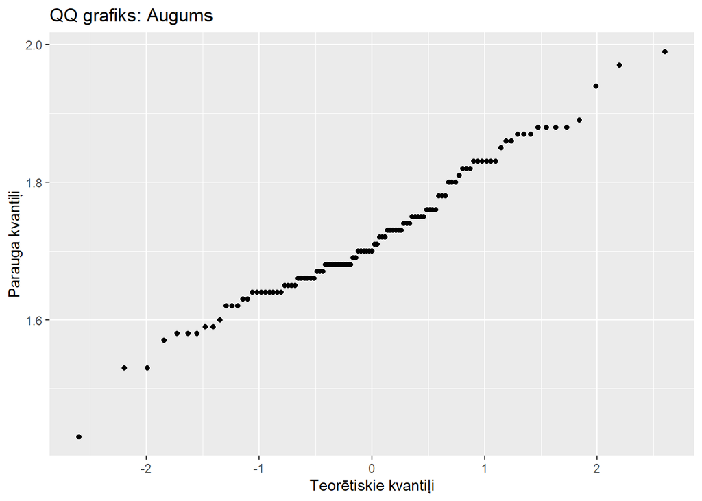

```r
# QQ grafiks par Augumu
p8 <- ggplot(diabetes_data, aes(sample=`Augums, m`)) +
  geom_qq() +
  ggtitle("QQ grafiks: Augums") +
  xlab("Teorētiskie kvantiļi") + ylab("Parauga kvantiļi")
print(p8)
```

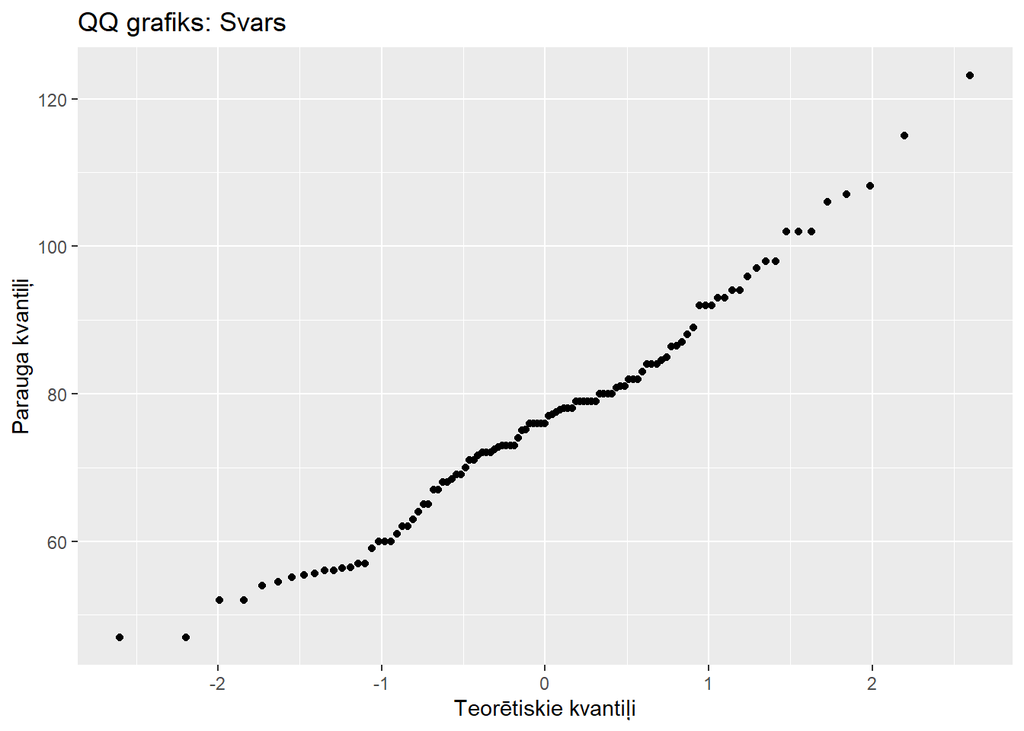

```r
# QQ grafiks par Svaru
qq_svars <- ggplot(diabetes_data, aes(sample=`Svars, kg`)) +
  geom_qq() +
  ggtitle("QQ grafiks: Svars") +
  xlab("Teorētiskie kvantiļi") + ylab("Parauga kvantiļi")
print(qq_svars)
```

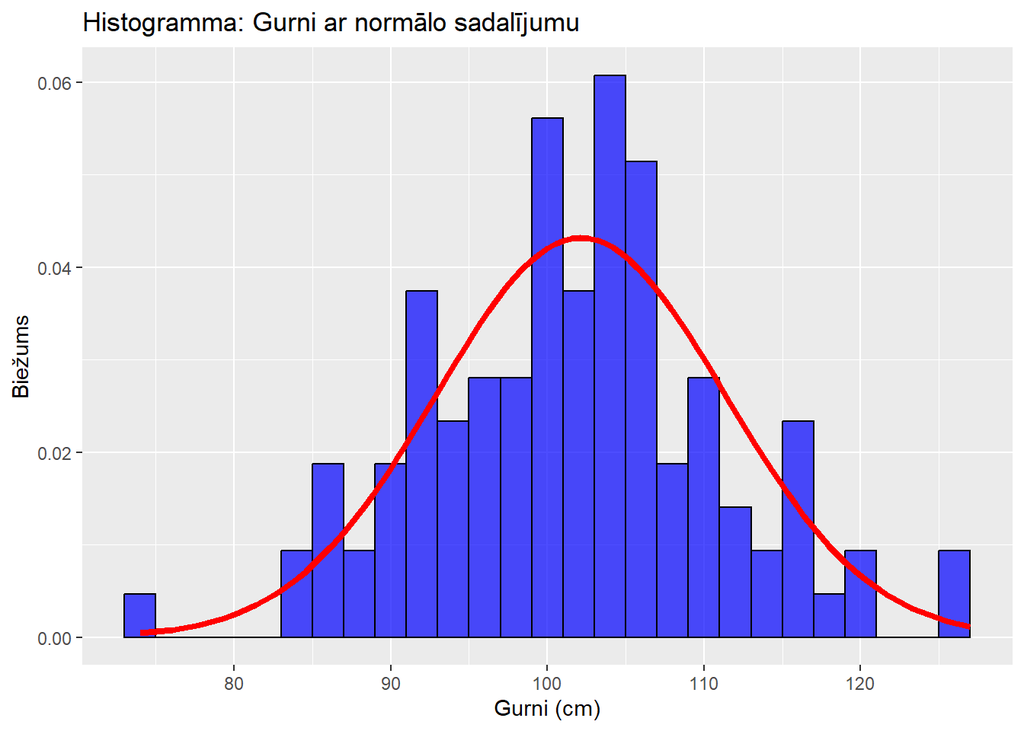

```r
# Histogramma Gurni ar normālo sadalījumu
hist_gurni_norm <- ggplot(diabetes_data, aes(x=`Gurni, cm`)) +
  geom_histogram(aes(y=..density..), binwidth=2, fill="blue", color="black", alpha=0.7) +
  stat_function(fun=dnorm, args=list(mean=mean(diabetes_data$`Gurni, cm`, na.rm=TRUE),
                                     sd=sd(diabetes_data$`Gurni, cm`, na.rm=TRUE)),
                color="red", size=1.5) +
  ggtitle("Histogramma: Gurni ar normālo sadalījumu") +
  xlab("Gurni (cm)") + ylab("Biežums")
print(hist_gurni_norm)
```

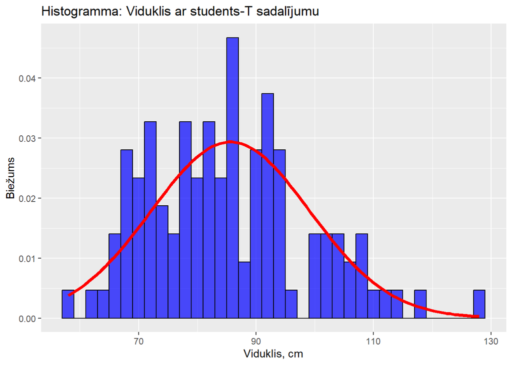

```r
# Histogramma Viduklis ar students-T sadalījumu
hist_viduklis_st <- ggplot(diabetes_data, aes(x=`Viduklis, cm`)) +
  geom_histogram(aes(y=..density..), binwidth=2, fill="blue", color="black", alpha=0.7) +
  stat_function(fun=function(x) dt((x - mean(diabetes_data$`Viduklis, cm`, na.rm=TRUE))
                / sd(diabetes_data$`Viduklis, cm`, na.rm=TRUE), df=107)
                / sd(diabetes_data$`Viduklis, cm`, na.rm=TRUE),
                color="red", size=1.5) +
  ggtitle("Histogramma: Viduklis ar students-T sadalījumu") +
  xlab("Viduklis, cm") + ylab("Biežums")
print(hist_viduklis_st)
```

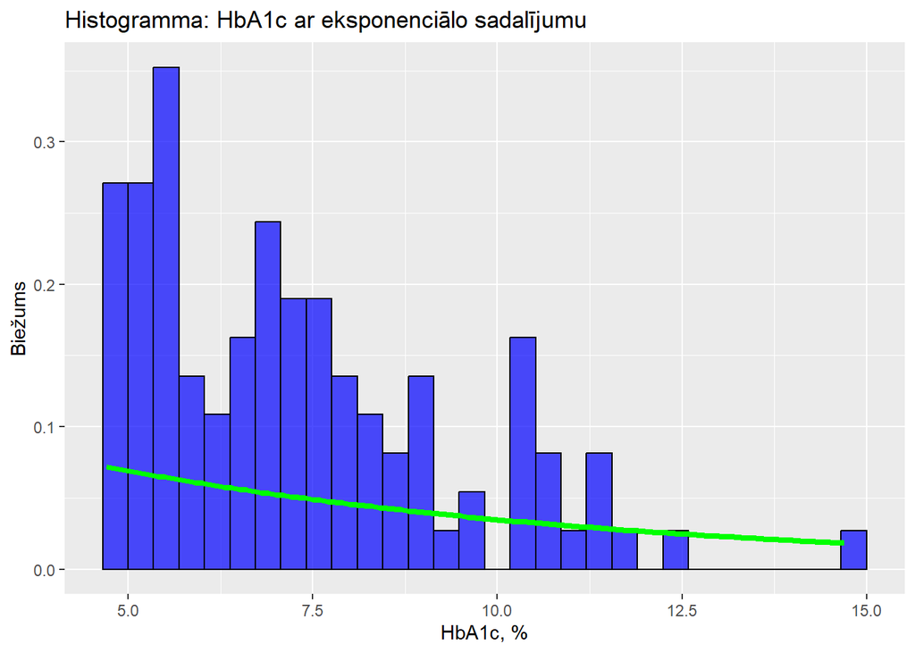

```r
# Histogramma HbA1c ar eksponenciālo sadalījumu. Sadalījums izskātās flatter nekā vajadzētu.
hist_hba1c_exp <- ggplot(diabetes_data, aes(x=`HbA1c, %`)) +
  geom_histogram(aes(y=..density..), fill="blue", color="black", alpha=0.7) +
  stat_function(fun=dexp, args=list(rate=1/mean(diabetes_data$`HbA1c, %`, na.rm=TRUE)),
                color="green", size=1.5) +
  ggtitle("Histogramma: HbA1c ar eksponenciālo sadalījumu") +
  xlab("HbA1c, %") + ylab("Biežums")
print(hist_hba1c_exp)
```

### Zinatniska analīze

Diabeta dati satur daudz informācijas par pacientiem, viņu veselības stāvokli, dzīvesveidu un citiem aspektiem. Lejā ir daži zinātniski jautājumi, ko varētu uzdot, un metodes, kuras varētu izmantot šo jautājumu atbildēšanai.

#### Pacientu demogrāfija un veselības rādītāji

**Jautājumi:** Vai ir kāda saistība starp dzimumu un diabēta smagumu (piemēram, HbA1c vērtības), Kāda ir saistība starp pacienta vecumu un citiem veselības rādītājiem, piemēram, asinsspiedienu vai holesterīna līmeni?

**Metodes**: Korelācijas analīze, t-testi, lineārās regresijas analīze

#### Dzīvesveids un veselības rādītāji

**Jautājumi:** Vai smeķēšana ietekmē diabēta smagumu vai citus veselības rādītājus? Kā medikamentu lietošana ietekmē pacientu veselības stāvokli?

**Metodes**: Chi-kvadrāta tests, loģistikās regresijas analīze

#### Diabēta terapija un tās efektivitāte

**Jautājumi:** Kāda ir saistība starp insulīna devu un HbA1c vērtībām? Vai pacienti, kuri lieto noteiktus medikamentus, uzrāda labākus veselības rādītājus?

**Metodes**: Korelācijas analīze, t-testi

#### Diabēta komplikācijas

**Jautājumi:** Kādi faktori palielina risku attīstīt diabēta komplikācijas, piemēram, retinopātiju vai nieru bojājumus? Kāda ir saistība starp HbA1c vērtībām un komplikāciju risku?

**Metodes**: Riska analīze, loģistikās regresijas analīze

#### Datu struktūra un sadalījums

**Jautājumi:** Kādi datu sadalījumi ir tipiski šajā datu kopā? Vai ir kādas neparastas vērtības vai izņēmumi?

**Metodes**: Deskriptīvā statistika, vizualizācija (histogrammas, kastu grafiki), outlieru noteikšana

## 2. uzdevums

### LDA

```r
# 2. uzd.
library(caret)
library(MASS)

# Ielādējam datus
exam_data <- read_excel("homeworks\\data\\HW1\\2021_visi_kopa_1.xlsx")
# Notīram rindiņas, kurās ir vārds "atbr."
exam_data <- exam_data[!apply(exam_data, 1, function(row) any(grepl("atbr.", row))), ]

set.seed(777)

# Sajaucam datus
exam_data <- exam_data[sample(nrow(exam_data)), ]

# Uzstādam eksāmenu tipu kā 1 vai 0 (1 - matemātikas eksāmens, 0 - citi eksāmeni)
exam_data$IsMath <- ifelse(exam_data$Parbaudijums == "mat", 1, 0)

# Pārveidojam kategoriju mainīgas par faktoriem
exam_data$dzimums <- as.factor(exam_data$dzimums)
exam_data$IsMath <- as.factor(exam_data$IsMath)

# Sadalam datus treniņu un testēšanas kopās
trainIndex <- createDataPartition(exam_data$IsMath, p = .8, list = FALSE, times = 1)

trainData <- exam_data[trainIndex, ]
testData  <- exam_data[-trainIndex, ]

# LDA
lda_model <- lda(IsMath ~ Procenti + dzimums, data=trainData)

# Veic prognozes izmantojot testēšanas datus
lda_pred <- predict(lda_model, testData)

# Nodrošinām, ka prognozēšanas un faktiskajiem testa datiem ir vienādi līmeņi
levels(lda_pred$class) <- levels(testData$IsMath)

# Izveido sajaukšanas matricu
confusion <- confusionMatrix(lda_pred$class, testData$IsMath)
print(confusion)
```

```
## Confusion Matrix and Statistics
##
##           Reference
## Prediction    0    1
##          0 6292 1572
##          1  662 1388
##
##                Accuracy : 0.7747
##                  95% CI : (0.7663, 0.7829)
##     No Information Rate : 0.7014
##     P-Value [Acc > NIR] : < 2.2e-16
##
##                   Kappa : 0.4099
##
##  Mcnemar's Test P-Value : < 2.2e-16
##
##             Sensitivity : 0.9048
##             Specificity : 0.4689
##          Pos Pred Value : 0.8001
##          Neg Pred Value : 0.6771
##              Prevalence : 0.7014
##          Detection Rate : 0.6347
##    Detection Prevalence : 0.7932
##       Balanced Accuracy : 0.6869
##
##        'Positive' Class : 0
##
```

```r
# Aprēķina precizitāti
accuracy <- sum(diag(confusion$table)) / sum(confusion$table)
print(paste("Precizitāte:", round(accuracy, 3)))
```

```
## [1] "Precizitāte: 0.775"
```

### Skolas

```r
# Skaitīt cik reizes katra skola parādās datu kopā
skolu_skaititajs <- table(exam_data$IzglītībasIestāde)

# Izvēlēties lielākās skolas (piemēram, top 10)
lielakas_skolas <- names(skolu_skaititajs[order(skolu_skaititajs, decreasing = TRUE)][1:10])

# Izveidot jaunu mainīgo par skolu klasi
exam_data$SkolaKlase <- ifelse(exam_data$IzglītībasIestāde %in% lielakas_skolas, exam_data$IzglītībasIestāde, 'Citas')

# Pārveidojam kategoriju mainīgas par faktoriem
exam_data$SkolaKlase <- as.factor(exam_data$SkolaKlase)

# Sadalam datus treniņu un testēšanas kopās
set.seed(777)
trainIndex <- createDataPartition(exam_data$SkolaKlase, p = .8, list = FALSE, times = 1)
trainData <- exam_data[trainIndex, ]
testData  <- exam_data[-trainIndex, ]

# Veicam LDA izmantojot izvēlētās kolonnas kā ieejas datus
lda_model <- lda(SkolaKlase ~ IsMath + Procenti + dzimums, data=trainData)

# Nodrošinām, ka prognozes klasēm ir tādi paši līmeņi kā testa datiem
lda_pred$class <- factor(lda_pred$class, levels = levels(trainData$SkolaKlase))

# Veicam prognozes izmantojot testēšanas datus
lda_pred <- predict(lda_model, testData)

# Izveidojam sajaukšanas matricu un aprēķinājam precizitāti
confusion <- confusionMatrix(lda_pred$class, testData$SkolaKlase)
print(confusion)
```

```
## Confusion Matrix and Statistics
##
##                                                                                                     Reference
## Prediction                                                                                           Citas
##   Citas                                                                                               8199
##   Jelgavas Tehnikums (prof.)                                                                             0
##   Ogres tehnikums (prof.)                                                                                0
##   Profesionālās izglītības kompetences centrs "Liepājas Valsts tehnikums" (prof.)                        0
##   Profesionālās izglītības kompetences centrs "Rīgas Tehniskā koledža"                                   0
##   Profesionālās izglītības kompetences centrs "Rīgas Valsts tehnikums" (prof.)                           0
##   Rīgas 1. Tālmācības vidusskola                                                                         0
##   Rīgas Mākslas un mediju tehnikums (prof.)                                                              0
##   Rīgas Tālmācības vidusskola                                                                            0
##   Rīgas Valsts 1. ģimnāzija                                                                              0
##   Valsts sabiedrība ar ierobežotu atbildību "Rīgas Tūrisma un radošās industrijas tehnikums" (prof.)     0
##                                                                                                     Reference
## Prediction                                                                                           Jelgavas Tehnikums (prof.)
##   Citas                                                                                                                     143
##   Jelgavas Tehnikums (prof.)                                                                                                  0
##   Ogres tehnikums (prof.)                                                                                                     0
##   Profesionālās izglītības kompetences centrs "Liepājas Valsts tehnikums" (prof.)                                             0
##   Profesionālās izglītības kompetences centrs "Rīgas Tehniskā koledža"                                                        0
##   Profesionālās izglītības kompetences centrs "Rīgas Valsts tehnikums" (prof.)                                                0
##   Rīgas 1. Tālmācības vidusskola                                                                                              0
##   Rīgas Mākslas un mediju tehnikums (prof.)                                                                                   0
##   Rīgas Tālmācības vidusskola                                                                                                 0
##   Rīgas Valsts 1. ģimnāzija                                                                                                   0
##   Valsts sabiedrība ar ierobežotu atbildību "Rīgas Tūrisma un radošās industrijas tehnikums" (prof.)                          0
##                                                                                                     Reference
## Prediction                                                                                           Ogres tehnikums (prof.)
##   Citas                                                                                                                  147
##   Jelgavas Tehnikums (prof.)                                                                                               0
##   Ogres tehnikums (prof.)                                                                                                  0
##   Profesionālās izglītības kompetences centrs "Liepājas Valsts tehnikums" (prof.)                                          0
##   Profesionālās izglītības kompetences centrs "Rīgas Tehniskā koledža"                                                     0
##   Profesionālās izglītības kompetences centrs "Rīgas Valsts tehnikums" (prof.)                                             0
##   Rīgas 1. Tālmācības vidusskola                                                                                           0
##   Rīgas Mākslas un mediju tehnikums (prof.)                                                                                0
##   Rīgas Tālmācības vidusskola                                                                                              0
##   Rīgas Valsts 1. ģimnāzija                                                                                                0
```

[output cut: 194 more lines]

```
## Pos Pred Value                                    NaN
## Neg Pred Value                                0.98395
## Prevalence                                    0.01605
## Detection Rate                                0.00000
## Detection Prevalence                          0.00000
## Balanced Accuracy                             0.50000
##                      Class: Valsts sabiedrība ar ierobežotu atbildību "Rīgas Tūrisma un radošās industrijas tehnikums" (prof.)
## Sensitivity                                                                                                            0.00000
## Specificity                                                                                                            1.00000
## Pos Pred Value                                                                                                             NaN
## Neg Pred Value                                                                                                         0.98365
## Prevalence                                                                                                             0.01635
## Detection Rate                                                                                                         0.00000
## Detection Prevalence                                                                                                   0.00000
## Balanced Accuracy                                                                                                      0.50000
```

```r
accuracy <- sum(diag(confusion$table)) / sum(confusion$table)
print(paste("Precizitāte:", round(accuracy, 3)))
```

```
## [1] "Precizitāte: 0.827"
```

**Komentārs**: Sajaukšanas matricas rezultāti sniedz dažus ievērojumus. Vispārējā precizitāte ir 0,827. Tas nozīmē, ka no visiem paredzētajiem rezultātiem aptuveni 82,7% bija pareizi. Tomēr, ņemot vērā, ka visu klases modelis tiek paredzēts kā “Citas”, šāda precizitāte nav tik augsta, kā varētu šķist. Vēl viens svarīgs rādītājs ir Kappa statistika, kas šajā gadījumā ir 0. Vērtība 0 norāda, ka modelis neparedz labāk nekā nejaušība. Ja mēs pievēršamies atsevišķām klasēm, redzam, ka visām klasēm, izņemot “Citas”, sensitivitāte ir 0. Tas nozīmē, ka modelis nav spējīgs pareizi identificēt nevienu no šīm klasēm. Tāpēc, lai gan kopējā precizitāte šķiet augsta, modelis faktiski nespēj pareizi klasificēt lielāko daļu skolu, kuras jūs mēģināt prognozēt. Tas ir diezgan logiski, jo nekādas ekonomiskas sakarības starp skolam, dzimumiem un eksāmenu rezultātiem nav.

### Naive Bayes

```r
library(e1071)

# Sadalam datus treniņu un testēšanas kopās
trainIndex <- createDataPartition(exam_data$IsMath, p = .8, list = FALSE, times = 1)
trainData <- exam_data[trainIndex, ]
testData  <- exam_data[-trainIndex, ]

# Naive Bayes
nb_model <- naiveBayes(IsMath ~ dzimums + Punkti, data=trainData)
nb_pred <- predict(nb_model, testData)
confusion_nb <- confusionMatrix(nb_pred, testData$IsMath)
print(confusion_nb)
```

```
## Confusion Matrix and Statistics
##
##           Reference
## Prediction    0    1
##          0 5703  824
##          1 1251 2136
##
##                Accuracy : 0.7907
##                  95% CI : (0.7826, 0.7987)
##     No Information Rate : 0.7014
##     P-Value [Acc > NIR] : < 2.2e-16
##
##                   Kappa : 0.5202
##
##  Mcnemar's Test P-Value : < 2.2e-16
##
##             Sensitivity : 0.8201
##             Specificity : 0.7216
##          Pos Pred Value : 0.8738
##          Neg Pred Value : 0.6306
##              Prevalence : 0.7014
##          Detection Rate : 0.5752
##    Detection Prevalence : 0.6584
##       Balanced Accuracy : 0.7709
##
##        'Positive' Class : 0
##
```

## 3. uzdevums

#### Pierādījums, ka divu Puasona gadījumu lielumu summa ir arī sadalīta pēc Puasona sadalījuma:

Ja mums ir divas neatkarīgas gadījumu lielumus $X$ un $Y$, kuras abas ir sadalītas pēc Puasona sadalījuma ar intensitātes parametriem $\lambda_1$ un $\lambda_2$ attiecīgi, tad to summa $Z = X + Y$ ir arī sadalīta pēc Puasona sadalījuma ar intensitātes parametru $\lambda = \lambda_1 + \lambda_2$.

**Pierādījums**: Mums jāaprēķina varbūtība $P(Z = k)$, kur $Z$ ir summa $X + Y$.
$$P(Z = k) = \sum_{i=0}^{k} P(X
= i) \times P(Y = k - i)$$
Ņemot vērā, ka $X$ un $Y$ ir sadalīti pēc Puasona sadalījuma:
$$P(X = i) = \frac{e^{-\lambda_1}
\lambda_1^i}{i!}$$
$$P(Y = j) =
\frac{e^{-\lambda_2} \lambda_2^j}{j!}$$
Ievietojot šīs vērtības iepriekšējā izteiksmē, mēs redzam, ka summa visiem $k$ uzvedas kā Puasona sadalījums ar parametru $\lambda = \lambda_1 + \lambda_2$.

#### Varbūtības aprēķins:

Lai aprēķinātu varbūtību, ka ciematā nākamā gada laikā nebūs vairāk kā 8 elektrības pārrāvumi, mums jāaprēķina varbūtība $P(Z \leq 8)$, kur $Z$ ir summa $X + Y$.

No dotajām vērtībām: $\lambda_1 = 3$ (pārrāvumi dēļ remontdarbiem) $\lambda_2 = 4$ (pārrāvumi dēļ laikapstākļiem) Tādējādi $\lambda = \lambda_1 + \lambda_2 = 7$.

$$P(Z \leq 8) = \sum_{i=0}^{8}
\frac{e^{-7} \times 7^i}{i!}$$

Pusgada varbūtība būtu: $\lambda' = \frac{\lambda}{2} = 3.5$

$$P(Z' \leq 8) = \sum_{i=0}^{8}
\frac{e^{-3.5} \times 3.5^i}{i!}$$

```r
# 3. uzdevums
lambda_1 <- 3
lambda_2 <- 4
lambda <- lambda_1 + lambda_2

p_year <- sum(dpois(0:8, lambda))

lambda_half <- lambda / 2
p_half_year <- sum(dpois(0:8, lambda_half))

print(paste("Varbūtība gadā: ", p_year))
```

```
## [1] "Varbūtība gadā:  0.729091267738082"
```

```r
print(paste("Varbūtība pusgadā: ", p_half_year))
```

```
## [1] "Varbūtība pusgadā:  0.990126341943895"
```